# Introduction

Here we will look at plots from from the DIPTSUR2 SWMF simulation run, and the LUHMANN1979 simple analytic magnetosphere model.

The DIPTSUR2 run was an MHD simulation run on a block tree grid, with grid points and field values outputted to a data-file (eventually converted to VTU).

[figure not shown]

which includes a callable function for magnetic field. This function was then evaluated at each point of the DIPTSUR2 run grid, in order to make a mock VTU file.

All the plots shown in the next section were done using points sampled from this native block tree grid.

The three SWMF variables used here are: "b", "b1", "j". Here "b" represents the full magnetic field, "b1" represent the magnetic field minus the contribution from the earths dipole field, and "j" represents the current density.

In the DIPTSUR2 run, "j" is not actually part of the simulation equations. Supposedly "j" is calculated as the curl of "b1" (multiplied by mu_0) evaluated on the native block tree grid, using a discrete derivative formula. If this is this case, then I would expect taking the discrete curl of "b1" from the data-file to exactly reproduce "j".

In the LUHMANN1979 mock run, the magnetic field model includes a dipole term, and a non dipole term $B(x,y,z) = B_{dipole}(x,y,z) + B_T \tanh(\frac{z}{\delta}) e_x$. In this example we took $B_T = 100nT$, $\delta=3R_e$, and earth magnetic moment of $3.12\cdot 10^4 \cdot nT \cdot R_e^3$. Here "b" was taken to be the full magnetic field and "b1" the non dipole term, evaluated at the native grid points. Then, the analytic magnetic field function was analytically differentiated to get the curl. This analytic curl, multiplied by mu_0, was evaluated at the grid points to get "j". As a result, taking a discrete derivative approximation of "b" is **not** expected to *exactly* reproduce "j".

# Plots

## LUHMANN1979

We first will plot histograms of "b" and "b1" to get an idea of the characteristic value in nanotesla.

!>>>>>>>>>>>>>>>>>>>>>>>>>>>>>>>>>>>>>>>>>>>>>>>>>>>>>>>>>>>>>>>>>>>>>>>>>>>>

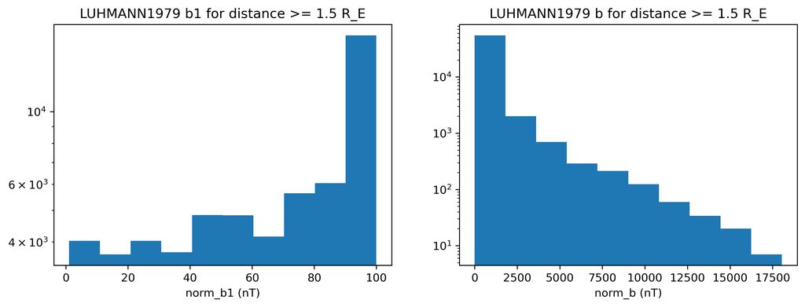

!<<<<<<<<<<<<<<<<<<<<<<<<<<<<<<<<<<<<<<<<<<<<<<<<<<<<<<<<<<<<<<<<<<<<<<<<<<<<

So the characteristic value of "b1" seems to be about 50 nT, and the characteristic value of "b" is around 10000 nT.

Now let us plot the divergences divided by these characteristic values. Note this has units of $\frac{1}{R_E}$

!>>>>>>>>>>>>>>>>>>>>>>>>>>>>>>>>>>>>>>>>>>>>>>>>>>>>>>>>>>>>>>>>>>>>>>>>>>>>

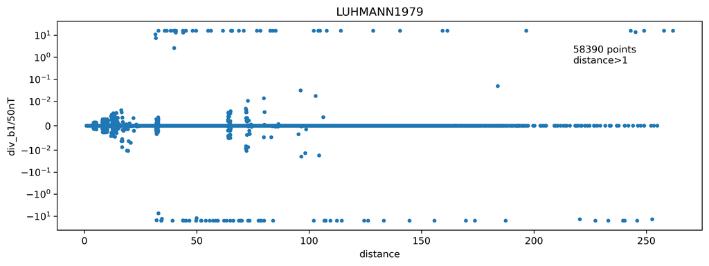

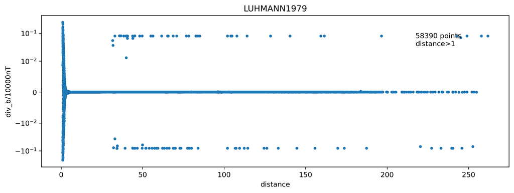

!<<<<<<<<<<<<<<<<<<<<<<<<<<<<<<<<<<<<<<<<<<<<<<<<<<<<<<<<<<<<<<<<<<<<<<<<<<<<

Now lets look at the error in amperes law, using both "b" and "b1".

!>>>>>>>>>>>>>>>>>>>>>>>>>>>>>>>>>>>>>>>>>>>>>>>>>>>>>>>>>>>>>>>>>>>>>>>>>>>>

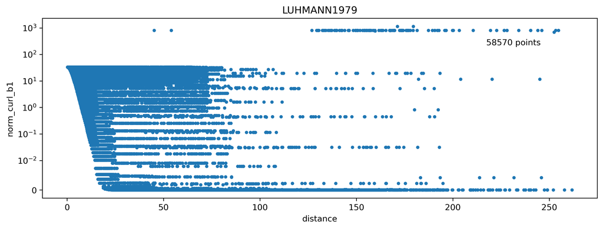

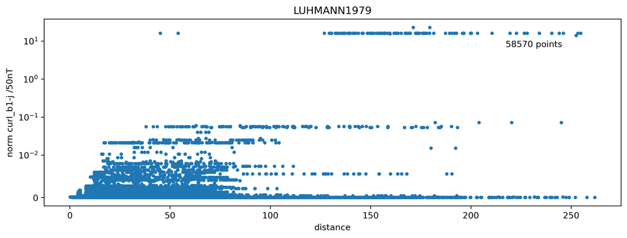

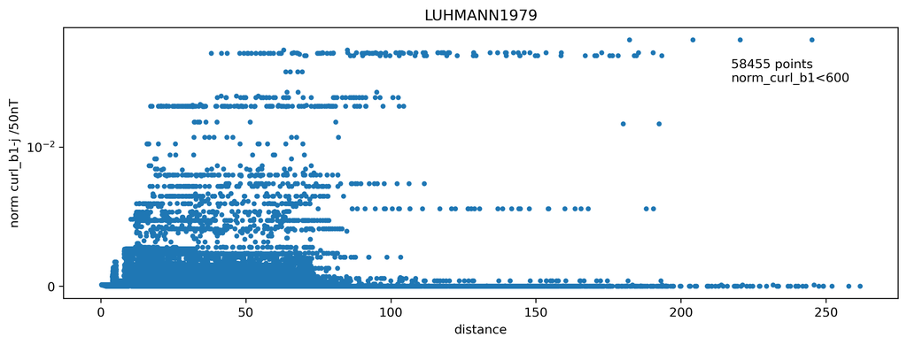

```
#####    difference in points: 115
```

!<<<<<<<<<<<<<<<<<<<<<<<<<<<<<<<<<<<<<<<<<<<<<<<<<<<<<<<<<<<<<<<<<<<<<<<<<<<<

Now lets put back the dipole and look at "b"

!>>>>>>>>>>>>>>>>>>>>>>>>>>>>>>>>>>>>>>>>>>>>>>>>>>>>>>>>>>>>>>>>>>>>>>>>>>>>

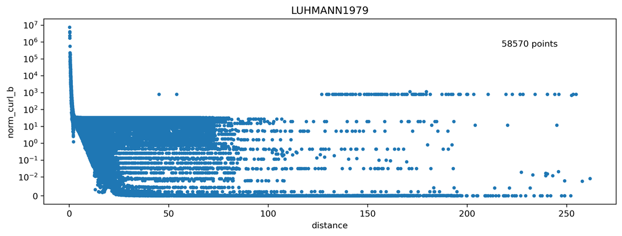

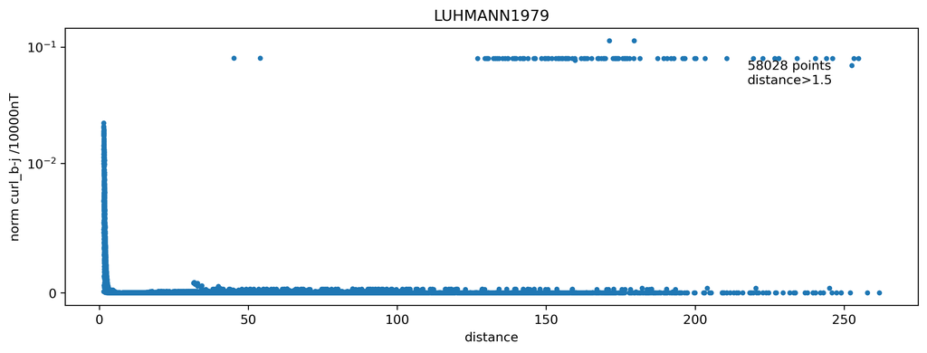

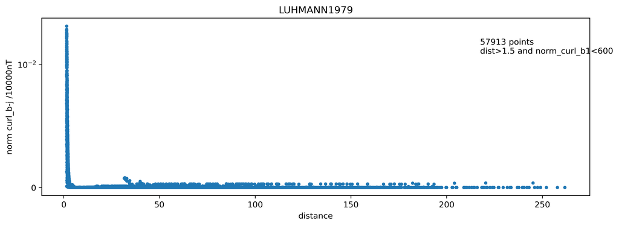

!<<<<<<<<<<<<<<<<<<<<<<<<<<<<<<<<<<<<<<<<<<<<<<<<<<<<<<<<<<<<<<<<<<<<<<<<<<<<

## DIPTSUR2

We now essentially repeat the process for DIPTSUR2

!>>>>>>>>>>>>>>>>>>>>>>>>>>>>>>>>>>>>>>>>>>>>>>>>>>>>>>>>>>>>>>>>>>>>>>>>>>>>

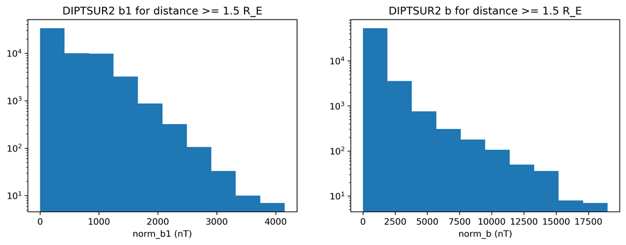

!<<<<<<<<<<<<<<<<<<<<<<<<<<<<<<<<<<<<<<<<<<<<<<<<<<<<<<<<<<<<<<<<<<<<<<<<<<<<

So the characteristic value of "b1" seems to be about 2000 nT, and the characteristic value of "b" is around 10000 nT. Note the "b" characteristic is the same as that for LUHMANN1979, indicating the dipole strength is the same.

Now let us plot the divergences divided by these characteristic values. Note this has units of $\frac{1}{R_E}$

!>>>>>>>>>>>>>>>>>>>>>>>>>>>>>>>>>>>>>>>>>>>>>>>>>>>>>>>>>>>>>>>>>>>>>>>>>>>>

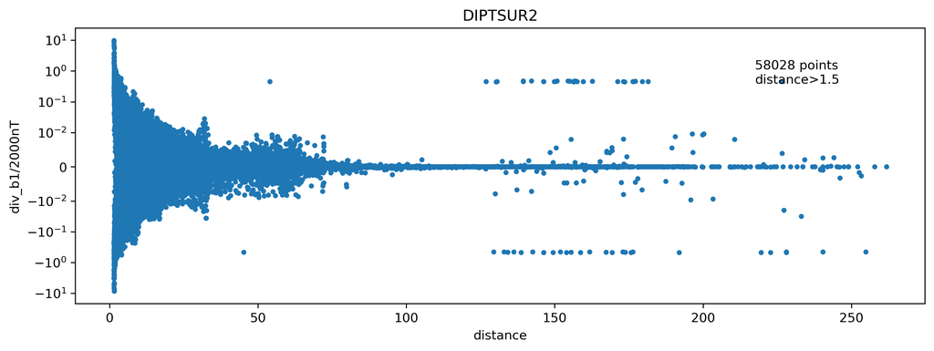

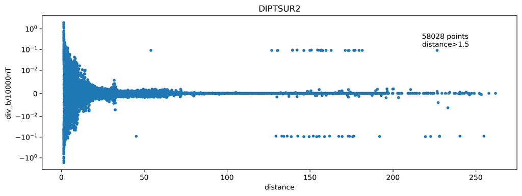

!<<<<<<<<<<<<<<<<<<<<<<<<<<<<<<<<<<<<<<<<<<<<<<<<<<<<<<<<<<<<<<<<<<<<<<<<<<<<

Now lets look at the error in amperes law, using both "b" and "b1".

!>>>>>>>>>>>>>>>>>>>>>>>>>>>>>>>>>>>>>>>>>>>>>>>>>>>>>>>>>>>>>>>>>>>>>>>>>>>>

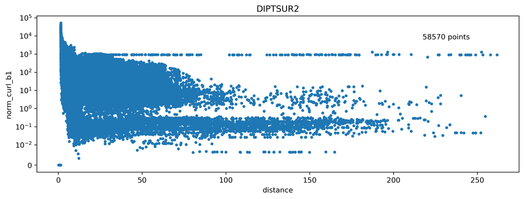

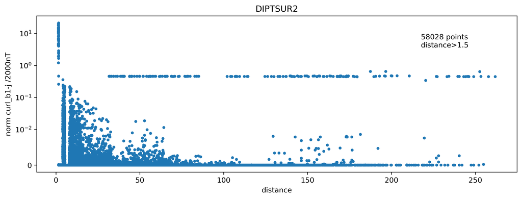

!<<<<<<<<<<<<<<<<<<<<<<<<<<<<<<<<<<<<<<<<<<<<<<<<<<<<<<<<<<<<<<<<<<<<<<<<<<<<

Now lets put back the dipole and look at "b"

!>>>>>>>>>>>>>>>>>>>>>>>>>>>>>>>>>>>>>>>>>>>>>>>>>>>>>>>>>>>>>>>>>>>>>>>>>>>>

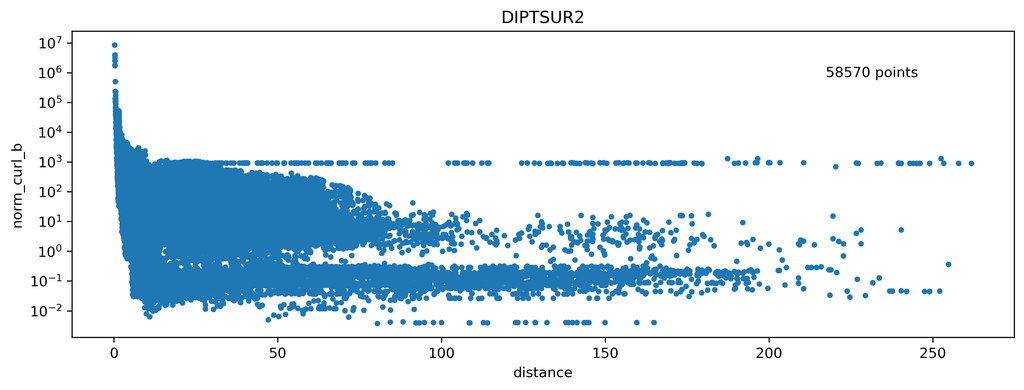

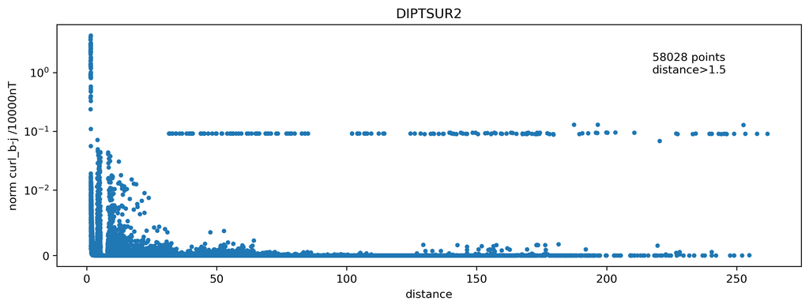

!<<<<<<<<<<<<<<<<<<<<<<<<<<<<<<<<<<<<<<<<<<<<<<<<<<<<<<<<<<<<<<<<<<<<<<<<<<<<